# Project: Investigate a Dataset - [tmdb-movies]

## Exploratory Data Analysis

> **Tip**: Now that you've trimmed and cleaned your data, you're ready to move on to exploration. **Compute statistics** and **create visualizations** with the goal of addressing the research questions that you posed in the Introduction section. You should compute the relevant statistics throughout the analysis when an inference is made about the data. Note that at least two or more kinds of plots should be created as part of the exploration, and you must compare and show trends in the varied visualizations.

> **Tip**: - Investigate the stated question(s) from multiple angles. It is recommended that you be systematic with your approach. Look at one variable at a time, and then follow it up by looking at relationships between variables. You should explore at least three variables in relation to the primary question. This can be an exploratory relationship between three variables of interest, or looking at how two independent variables relate to a single dependent variable of interest. Lastly, you should perform both single-variable (1d) and multiple-variable (2d) explorations.

### Research Question 1 (What is the relation between the revenue and other variables?)

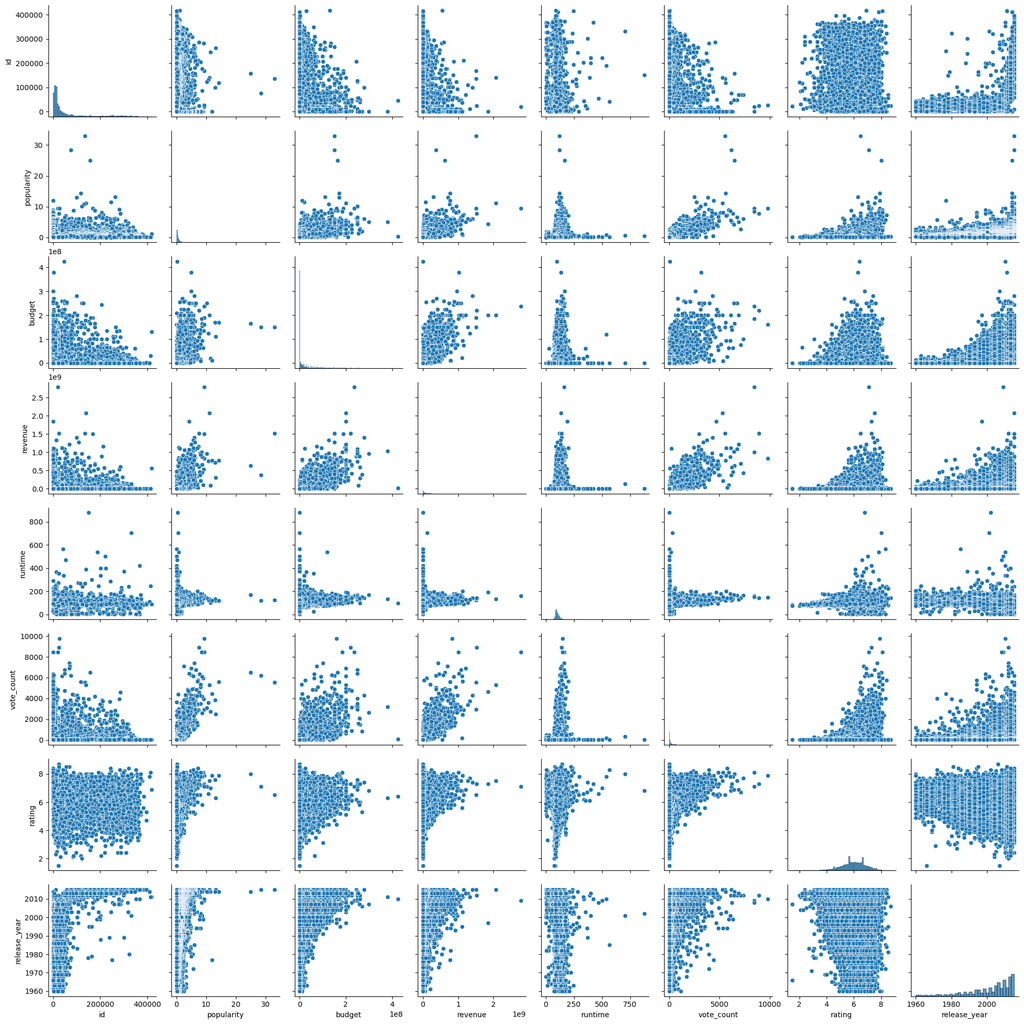

```python
sns.pairplot(tmdb_df);
```

```python
# I will check the correlation between Popularity and Revenue
```

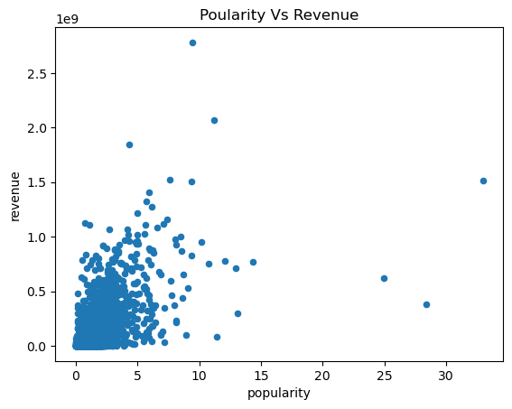

```python
# Function to plot the corrlation between variables
def corrlation(tmdb_df, x, y, title):
    tmdb_df.plot(x,y,kind='scatter')
    plt.title(title)
    plt.xlabel(x)
    plt.ylabel(y)

# Now the function is ready to use let's try it

# input data frame,xlable,ylable,title
corrlation(tmdb_df,'popularity','revenue','Poularity Vs Revenue')
```

## There is a corrlelation betwee popularity and revenue

```python
# I will check the correlation between Budget and Revenue
```

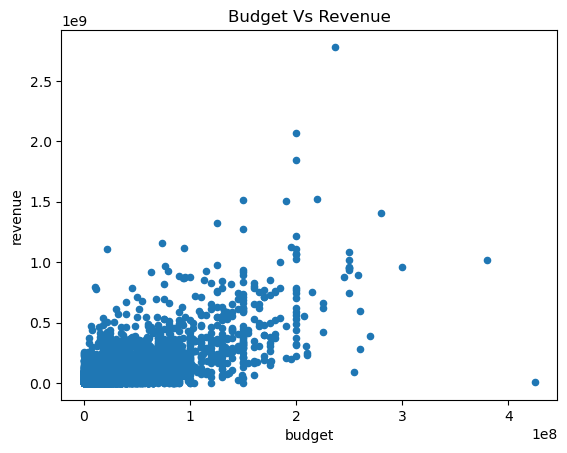

```python
# input data frame,xlable,ylable,title
corrlation(tmdb_df,'budget','revenue','Budget Vs Revenue')
```

```python
# I will check the correlation between Vote_Count and Revenue
```

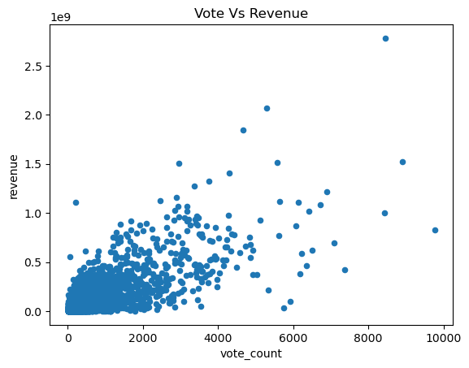

```python
# input data frame,xlable,ylable,title
corrlation(tmdb_df,'vote_count','revenue','Vote Vs Revenue')
```

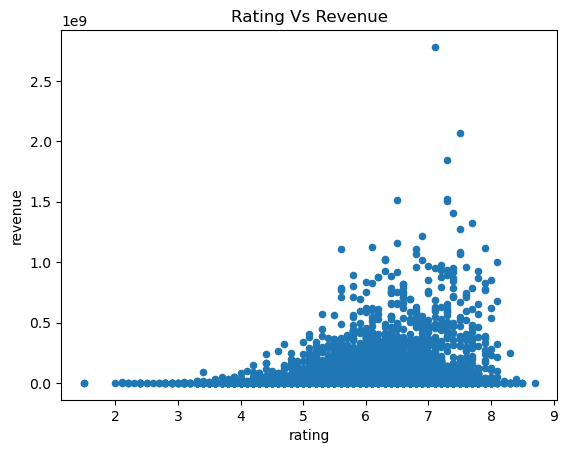

```python
# input data frame,xlable,ylable,title
corrlation(tmdb_df,'rating','revenue','Rating Vs Revenue')
```

# We observe that Revenue increases with an increase in Popularity and vote_count